# Modelling the Brain’s Response to Visual Stimuli

Rebecca Barter

11/14/2016

## fMRI

This case study examines data collected from a functional Magnetic Resonance Imaging (fMRI) experiment performed on a single individual by the Gallant neuroscience lab at UC Berkeley (see relevant papers by the Gallant lab [here](http://machinelearning.wustl.edu/mlpapers/paper_files/NIPS2008_0963.pdf) and [here](https://projecteuclid.org/download/pdfview_1/euclid.aoas/1310562717)).

fMRI measures oxygenated blood-flow in the brain which can be considered as an indirect measure of neural activity (the two processes are highly correlated). The measurements obtained from an fMRI experiment correspond to the aggregated response of hundreds of thousands of neurons within cube-like voxels of the brain, where the segmentation of the brain into 3D voxels is analogous to the segmentation of an image into 2D pixels.

## The data

The data contains the fMRI measurements (averaged over 10 runs of the experiment) for each of approximately 1,300 voxels located in the visual cortex of a single individual in response to viewings of 1,750 different images (such as a picture of a baby, a house or a horse).

Each image is a $128 \times 128$ pixel gray-scale image which can be represented by a vector of length $128^2 = 16,384$ but can be reduced to length $10,921$ through a [Gabor wavelet transformation](https://en.wikipedia.org/wiki/Gabor_wavelet).

The raw data is stored on the Collaborative Research in Computational Neuroscience (CRCNS) Data Sharing repository, and can be found [here](https://crcns.org/data-sets/vc/vim-1). Note that in order to access the data, you will need to request a CRCNS account in which you describe what you’re planning to do with the data, but this is fairly straightforward.

## Introducing Superheat

Installing the superheat package from github is easy, assuming you have the `devtools` package installed in R. Simply type the following command:

```r
# install devtools if you don't have it already
install.packages("devtools")
# install the development version of superheat
devtools::install_github("rlbarter/superheat")
```

Assuming that you didn’t run into any unfortunate errors when installing the package, you can load the package into R in the normal way.

```r
library(superheat)
```

## Viewing the raw images

```r
# some useful libraries
library(ggplot2)
library(dplyr)
library(gridExtra)
library(knitr)
library(RColorBrewer)
```

It is helpful to have an idea of what kind of images the subject was viewing. The raw images are contained in the `Stimuli.mat` file, and is separated into a set of 1,750 training images (used to train our models) and 120 validation images (used to evaluate model performance).

The code below loads in the data and extracts the training and validation images

```r
# a library for loading matlab files
library(R.matlab)
# load in the stimuli images
stimuli <- readMat("raw_data/Stimuli.mat")

# extract training stimuli array
train.stimuli <- stimuli[[1]]
# extract validation stimuli array
val.stimuli <- stimuli[[2]]
# remove the original stimuli object
rm(stimuli)
```

We display four of the training images below using our superheat package.

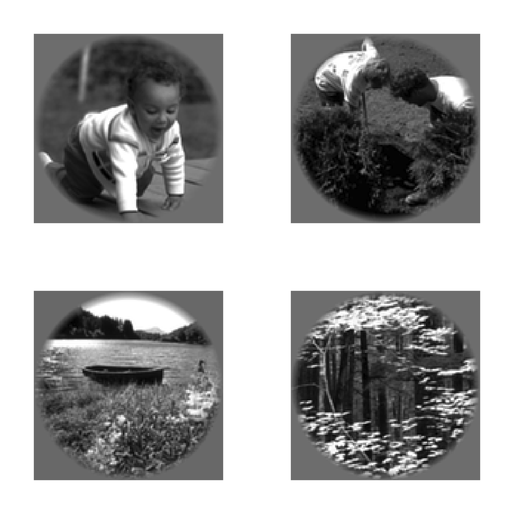

```r
# view some of the images
im1 <- superheat(train.stimuli[1, 128:1, ],
          heat.pal = c("black", "white"),
          legend = FALSE,
          print.plot = F)
im2 <- superheat(train.stimuli[3, 128:1, ],
          heat.pal = c("black", "white"),
          legend = FALSE,
          print.plot = F)
im3 <- superheat(train.stimuli[10, 128:1, ],
          heat.pal = c("black", "white"),
          legend = FALSE,
          print.plot = F)
im4 <- superheat(train.stimuli[15, 128:1, ],
          heat.pal = c("black", "white"),
          legend = FALSE,
          print.plot = F)

grid.arrange(im1$plot, im2$plot, im3$plot, im4$plot, ncol = 2)
```